# CHLA cell line proteomics

This document details the analysis of proteomics data acquired for comparison of the CHLA9 and CHLA10 cell lines.

## Setting up the environment

These are packages you will need for this notebook. For exact versions used, please refer to the session info at the bottom of this notebook.

```r
##########################################################################################
library('tidyverse')
library('RColorBrewer')
library('ggplot2')
library('DEqMS')
library('ggrepel')
```

I want to set a base directory that we can use as a link to the directory where we will do most of the work. I use two directories here because the Workspace is what is pushed to GitHub and contains scripts and plot files, but the Repository is where more of the big data is stored that does not get pushed.

```r
##########################################################################################
generalDatasets = 'C:/Users/chughes/Documents/bccrc/projectsRepository/generalDatasets'
baseWorkspace = 'C:/Users/chughes/Documents/bccrc/projectsWorkspace/sorensenLab/relatedToOthers'
baseRepository = 'C:/Users/chughes/Documents/bccrc/projectsRepository/sorensenLab/relatedToOthers'
#generalDatasets = 'C:/Users/chris/OneDrive/Documents/bccrc/projectsRepository/generalDatasets'
#baseWorkspace = 'C:/Users/chris/OneDrive/Documents/bccrc/projectsWorkspace/sorensenLab/relatedToYbx1'
#baseRepository = 'C:/Users/chris/OneDrive/Documents/bccrc/projectsRepository/sorensenLab/relatedToYbx1'
```

## Data processing

This is just a single batch, so we only have a single file we need to read in and process.

```r
##########################################################################################
psmId = read_tsv(paste(baseRepository, '/proteomics20210218_chlaCellLineProteomics/psm.tsv', sep = '')) %>%
  dplyr::select(Peptide, `Is Unique`, `Is Used`, `Protein ID`, Gene, chla9_rep1:chla10_rep3, hek293_rep1:hek293_rep3) %>%
  dplyr::rename(sequence = Peptide,
                unique = `Is Unique`,
                used = `Is Used`,
                accession = `Protein ID`,
                gene = Gene) %>%
  dplyr::filter(unique == TRUE, !grepl('CONT', accession), !is.na(gene), !grepl('-', gene)) %>%
  dplyr::rowwise(sequence, accession, gene) %>%
  dplyr::mutate(totalSignal = sum(c_across(chla9_rep1:hek293_rep3), na.rm = TRUE)) %>%
  dplyr::filter(totalSignal >= 100)
```

Now we can process these data with DEqMS.

Our sample layout is:

- 126C - chla9_rep1
- 127N - chla10_rep1
- 127C - chla9_rep2
- 128N - chla10_rep2
- 128C - chla9_rep3
- 129N - chla10_rep3
- 129C - empty
- 130N - empty
- 130C - hek293_rep1
- 131N - hek293_rep2
- 131C - hek293_rep3

We will also normalize the data to deal with any gross loading differences. We save both the non-normalized data here as well and check the normalization with a plot.

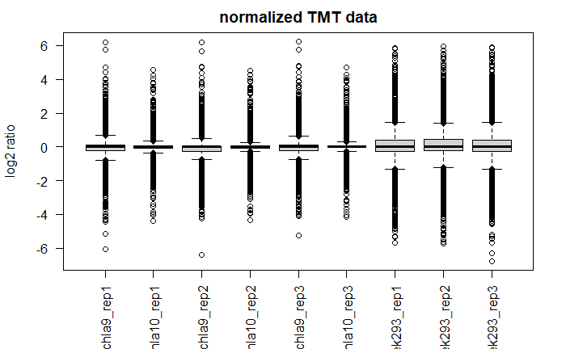

```r
##########################################################################################
quantInput = psmId[,c(1,5:14)]
saveRDS(quantInput, paste(baseRepository, '/proteomics20210218_chlaCellLineProteomics/dataset_peptideQuantDataPreDEqMS.rds', sep = ''))
quantInputLog = quantInput
quantInputLog[,3:11][quantInputLog[,3:11] == 0] = NA
quantInputLog[,3:11] = log2(quantInputLog[,3:11])
quantInputNormalized = medianSweeping(quantInputLog, group_col = 2)
boxplot(quantInputNormalized, las = 2, ylab = 'log2 ratio', main = 'normalized TMT data')
```

All of the data look tight. Good. Lets continue with the DEqMS analysis. We need to build our sample table.

```r
##########################################################################################
cond = as.factor(c('chla9','chla10','chla9','chla10','chla9','chla10','hek293','hek293','hek293'))
design = model.matrix(~0+cond)
colnames(design) = gsub('cond', '', colnames(design))
```

Now we can build the Limma model.

```r
##########################################################################################
geneMatrix = as.matrix(quantInputNormalized)
limmaFit1 = lmFit(geneMatrix, design)
```

```
Partial NA coefficients for 2 probe(s)
```

```r
limmaContrasts = c('chla9 - chla10', 'chla9 - hek293', 'chla10 - hek293')
limmaContrastDesign =  makeContrasts(contrasts = limmaContrasts, levels = design)
limmaFit2 = eBayes(contrasts.fit(limmaFit1, contrasts = limmaContrastDesign))
```

```r
##########################################################################################
psmCountTable = as.data.frame(table(quantInput$gene))
rownames(psmCountTable) = psmCountTable$Var1
limmaFit2$count = psmCountTable[rownames(limmaFit2$coefficients),2]
limmaFit3 = spectraCounteBayes(limmaFit2)
head(limmaFit3$coefficients)
```

```
       Contrasts
        chla9 - chla10 chla9 - hek293 chla10 - hek293
  A2M      -0.03435739      2.1215680       2.1559254
  AAAS     -0.46625430     -0.1950042       0.2712501
  AACS      0.17666889      0.2788723       0.1022034
  AAGAB    -0.97294383     -1.7185666      -0.7456227
  AAK1      0.08295313      0.8096075       0.7266544
  AAMDC     1.01353294      0.4928688      -0.5206641
```

```r
##
deqmsResults = outputResult(limmaFit3, coef_col = 1)
dim(deqmsResults)
```

```
[1] 7971   11
```

```r
saveRDS(deqmsResults, paste(baseRepository, '/proteomics20210218_chlaCellLineProteomics/dataset_deqms_chla9-chla10.rds', sep = ''))
write.table(deqmsResults,
            paste(baseRepository, '/proteomics20210218_chlaCellLineProteomics/dataset_deqms_chla9-chla10.csv', sep = ''),
            sep = ',', row.names = FALSE, quote = FALSE)
##
deqmsResults = outputResult(limmaFit3, coef_col = 2)
dim(deqmsResults)
```

```
[1] 7971   11
```

```r
write.table(deqmsResults,
            paste(baseRepository, '/proteomics20210218_chlaCellLineProteomics/dataset_deqms_chla9-hek293.csv', sep = ''),
            sep = ',', row.names = FALSE, quote = FALSE)
##
deqmsResults = outputResult(limmaFit3, coef_col = 3)
dim(deqmsResults)
```

```
[1] 7971   11
```

```r
write.table(deqmsResults,
            paste(baseRepository, '/proteomics20210218_chlaCellLineProteomics/dataset_deqms_chla10-hek293.csv', sep = ''),
            sep = ',', row.names = FALSE, quote = FALSE)
```

Generate the variance plot to see the DEqMS model for the data.

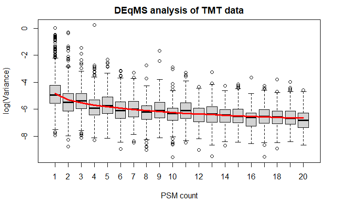

```r
##########################################################################################
VarianceBoxplot(limmaFit3, n=20, xlab = 'PSM count', main = 'DEqMS analysis of TMT data')
```

This looks as it should. Now let us make a volcano plot to show the data.

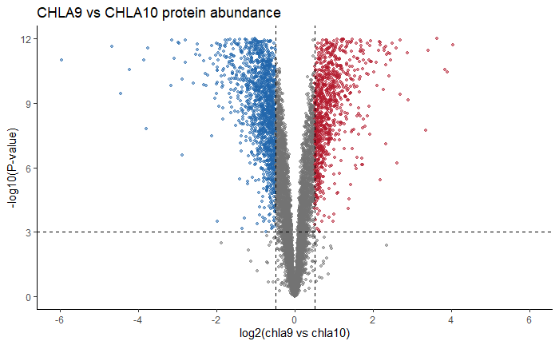

```r
##########################################################################################
deqmsResults = outputResult(limmaFit3, coef_col = 1)
deqmsResults$plotPValue = -log10(deqmsResults$sca.P.Value)
deqmsResults$pColors = ifelse(deqmsResults$logFC <= -0.5 & deqmsResults$plotPValue >= 3, brewer.pal(8,'RdBu')[8],
                              ifelse(deqmsResults$logFC >= 0.5 & deqmsResults$plotPValue >= 3, brewer.pal(8,'RdBu')[1],
                                     brewer.pal(8,'Greys')[6]))
deqmsResults$pText = ifelse(grepl('YBX1$',deqmsResults$gene), deqmsResults$gene, '')
##
ggplot(deqmsResults, aes(logFC, plotPValue)) +
  geom_point(size = 1, color = deqmsResults$pColors, alpha = 0.5) +
  geom_text_repel(label = deqmsResults$pText, nudge_x = -2) +
  labs(x = 'log2(chla9 vs chla10)', y = '-log10(P-value)', title = 'CHLA9 vs CHLA10 protein abundance') +
  scale_y_continuous(limits = c(0,12), breaks = seq(0,18,3)) +
  scale_x_continuous(limits = c(-6,6), breaks = seq(-6,6,2)) +
  geom_vline(xintercept = c(-0.5,0.5), linetype = 'dashed') +
  geom_hline(yintercept = 3, linetype = 'dashed') +
  theme_classic()
ggsave(paste(baseRepository, '/proteomics20210218_chlaCellLineProteomics/scatter_deqms_chla9-chla10.pdf', sep = ''),
       height = 4, width = 4, useDingbats = FALSE)
```

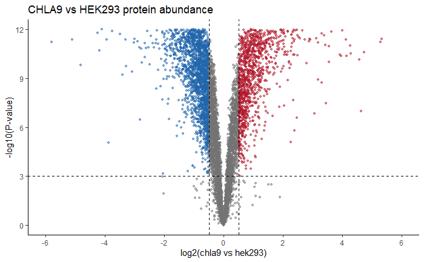

```r
##########################################################################################
deqmsResults = outputResult(limmaFit3, coef_col = 2)
deqmsResults$plotPValue = -log10(deqmsResults$sca.P.Value)
deqmsResults$pColors = ifelse(deqmsResults$logFC <= -0.5 & deqmsResults$plotPValue >= 3, brewer.pal(8,'RdBu')[8],
                              ifelse(deqmsResults$logFC >= 0.5 & deqmsResults$plotPValue >= 3, brewer.pal(8,'RdBu')[1],
                                     brewer.pal(8,'Greys')[6]))
deqmsResults$pText = ifelse(grepl('YBX1',deqmsResults$gene), deqmsResults$gene, '')
##
ggplot(deqmsResults, aes(logFC, plotPValue)) +
  geom_point(size = 1, color = deqmsResults$pColors, alpha = 0.5) +
  geom_text_repel(label = deqmsResults$pText, nudge_x = -2) +
  labs(x = 'log2(chla9 vs hek293)', y = '-log10(P-value)', title = 'CHLA9 vs HEK293 protein abundance') +
  scale_y_continuous(limits = c(0,12), breaks = seq(0,18,3)) +
  scale_x_continuous(limits = c(-6,6), breaks = seq(-6,6,2)) +
  geom_vline(xintercept = c(-0.5,0.5), linetype = 'dashed') +
  geom_hline(yintercept = 3, linetype = 'dashed') +
  theme_classic()
ggsave(paste(baseRepository, '/proteomics20210218_chlaCellLineProteomics/scatter_deqms_chla9-hek293.pdf', sep = ''),
       height = 4, width = 4, useDingbats = FALSE)
```

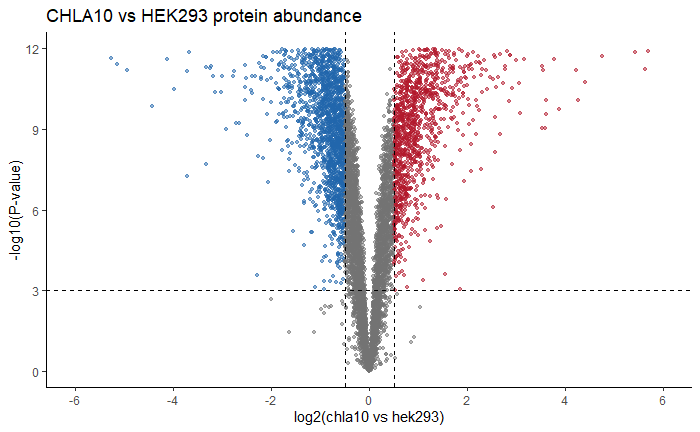

```r
##########################################################################################
deqmsResults = outputResult(limmaFit3, coef_col = 3)
deqmsResults$plotPValue = -log10(deqmsResults$sca.P.Value)
deqmsResults$pColors = ifelse(deqmsResults$logFC <= -0.5 & deqmsResults$plotPValue >= 3, brewer.pal(8,'RdBu')[8],
                              ifelse(deqmsResults$logFC >= 0.5 & deqmsResults$plotPValue >= 3, brewer.pal(8,'RdBu')[1],
                                     brewer.pal(8,'Greys')[6]))
deqmsResults$pText = ifelse(grepl('YBX1$',deqmsResults$gene), deqmsResults$gene, '')
##
ggplot(deqmsResults, aes(logFC, plotPValue)) +
  geom_point(size = 1, color = deqmsResults$pColors, alpha = 0.5) +
  geom_text_repel(label = deqmsResults$pText, nudge_x = -2) +
  labs(x = 'log2(chla10 vs hek293)', y = '-log10(P-value)', title = 'CHLA10 vs HEK293 protein abundance') +
  scale_y_continuous(limits = c(0,12), breaks = seq(0,18,3)) +
  scale_x_continuous(limits = c(-6,6), breaks = seq(-6,6,2)) +
  geom_vline(xintercept = c(-0.5,0.5), linetype = 'dashed') +
  geom_hline(yintercept = 3, linetype = 'dashed') +
  theme_classic()
ggsave(paste(baseRepository, '/proteomics20210218_chlaCellLineProteomics/scatter_deqms_chla10-hek293.pdf', sep = ''),
       height = 4, width = 4, useDingbats = FALSE)
```

[session information not shown]